# Projekt zaliczeniowy

Aleksandra Sikorska, Izabela Sprysak

```r
knitr::opts_chunk$set(
  message = FALSE,
  warning = FALSE
)
```

# 1. Wczytanie potrzebnych pakietów

```r
# 1. Wczytanie potrzebnych pakietów ----

library(tm)
library(tidyverse)
library(tidytext)
library(topicmodels)
library(wordcloud)
```

# 2. Wczytanie danych tekstowych

```r
# 2. Wczytanie danych tekstowych ----

# Wczytanie danych z pliku reviews.csv
data <- read.csv("reviews.csv", sep = ";", stringsAsFactors = FALSE, encoding = "UTF-8")
```

> Dane to opinie pracowników. Podzielone są na “best thing”, “worst thing” i “entire review”. Podział ten jest zachowany w dalszej analizie. Chmury słów stworzone są dla każdej kategorii osobno. Topic modelling przeprowadzony jest na “best thing” i “worst thing”. Natomiast asocjacje przeprowadzone są na “entire review”.

```r
corpus_best_thing <- VCorpus(VectorSource(data$best_thing))
corpus_worst_thing <- VCorpus(VectorSource(data$worst_thing))
corpus_entire_review <- VCorpus(VectorSource(data$entire_review))
```

# 3. Przetwarzanie i oczyszczanie tekstu

```r
# 3. Przetwarzanie i oczyszczanie tekstu ----

# Funkcja czyszcząca tekst

clean_corpus <- function(corpus) {

  # Kodowanie w całym korpusie
  corpus <- tm_map(corpus, content_transformer(function(x) iconv(x, to = "UTF-8", sub = "byte")))
  # Funkcja do zamiany znaków na spację
  toSpace <- content_transformer(function (x, pattern) gsub(pattern, " ", x))
  # Usunięcie \n
  corpus <- tm_map(corpus, toSpace, "\n")
  # Zmiana liter na małe
  corpus <- tm_map(corpus, content_transformer(tolower))
  # Usunięcie cyfr
  corpus <- tm_map(corpus, removeNumbers)
  # Usunięcie angielskich stopwords
  corpus <- tm_map(corpus, removeWords, stopwords("english"))
  # Usunięcie interpunkcji
  corpus <- tm_map(corpus, removePunctuation)
  # Usunięcie "dont" i "cant", które pozostają w innym przypadku
  corpus <- tm_map(corpus, removeWords, c("dont", "cant", "isnt"))
  # Usunięcie nadmiarowych spacji
  corpus <- tm_map(corpus, stripWhitespace)
}

# Czyszczenie korpusów
corpus_best_thing <- clean_corpus(corpus_best_thing)
corpus_worst_thing <- clean_corpus(corpus_worst_thing)
corpus_entire_review <- clean_corpus(corpus_entire_review)


corpus_best_thing[[1]][[1]]
```

```
## [1] " happy working field interested "
```

# 4. Stemming

```r
# 4. Stemming ----

# Zachowanie kopii korpusu
# do użycia jako dictionary w uzupełnianiu rdzeni
corpus_best_thing_copy <- corpus_best_thing
corpus_worst_thing_copy <- corpus_worst_thing
corpus_entire_review_copy <- corpus_entire_review

# Funkcja pomocnicza: wykonuje stemCompletion linia po linii
complete_stems <- content_transformer(function(x, dict) {
  x <- unlist(strsplit(x, " "))                  # dzieli na słowa
  x <- stemCompletion(x, dictionary = dict, type="prevalent") # uzupełnia rdzenie
  paste(x, collapse = " ")                       # łączy z powrotem w tekst
})

# Funkcja do zamiany znaków na spację
toSpace <- content_transformer(function (x, pattern) gsub(pattern, " ", x))

# Funkcja wykonująca stemming i stemCompletion
stemming <- function(corpus) {
  # Utworzenie kopii korpusu
  corpus_copy <- corpus
  # Wykonanie stemmingu
  corpus_stemmed <- tm_map(corpus, stemDocument)

  # Wykonanie stemCompletion do każdego dokumentu w korpusie
  corpus_completed <- tm_map(corpus_stemmed, complete_stems, dict = corpus_copy)

  # usunięcie NA
  corpus_completed <- tm_map(corpus_completed, toSpace, "NA")
  corpus_completed <- tm_map(corpus_completed, stripWhitespace)

  return(corpus_completed)
}


completed_corpus_best_thing <- stemming(corpus_best_thing)
completed_corpus_worst_thing <- stemming(corpus_worst_thing)
completed_corpus_entire_review <- stemming(corpus_entire_review)
```

# 5. Tokenizacja

```r
# 5. Tokenizacja ----

# Macierz częstości TDM ----

# Funkcja tworząca macierz częstości TDM + stemCompletion

create_tdm <- function(corpus) {
  tdm <- TermDocumentMatrix(corpus)
  return(tdm)
}

create_tdm_m <- function(corpus) {
  tdm <- TermDocumentMatrix(corpus)
  tdm_m <- as.matrix(tdm)
  return(tdm_m)
}


# Utworzenie macierzy częstości TDM dla wszystkich korpusów

tdm_m_best_thing <- create_tdm_m(completed_corpus_best_thing)
tdm_m_worst_thing <- create_tdm_m(completed_corpus_worst_thing)
tdm_m_entire_review <- create_tdm_m(completed_corpus_entire_review)

tdm_best_thing <- create_tdm(completed_corpus_best_thing)
tdm_worst_thing <- create_tdm(completed_corpus_worst_thing)
tdm_entire_review <- create_tdm(completed_corpus_entire_review)
```

# 6. Chmura słów

```r
# 6. Chmura słów ----

# Funkcja obliczająca częstość występowania słów

word_frequency <- function(tdm_m) {
  appearance_count <- sort(rowSums(tdm_m), decreasing = TRUE)
  tdm_data_frame <- data.frame(word = names(appearance_count), frequency = appearance_count)
  return(tdm_data_frame)
}

# Utworzenie ramek danych z częstością słów
tdm_best_thing_df <- word_frequency(tdm_m_best_thing)
tdm_worst_thing_df <- word_frequency(tdm_m_worst_thing)
tdm_entire_review_df <- word_frequency(tdm_m_entire_review)

head(tdm_best_thing_df, 10)
```

|  | word | frequency |
| --- | --- | --- |
| work | work | 17 |
| coffee | coffee | 16 |
| team | team | 15 |
| customers | customers | 11 |
| shift | shift | 11 |
| make | make | 10 |
| free | free | 8 |
| good | good | 8 |
| people | people | 7 |
| day | day | 6 |

```r
head(tdm_worst_thing_df, 10)
```

|  | word | frequency |
| --- | --- | --- |
| work | work | 21 |
| hours | hours | 18 |
| management | management | 17 |
| get | get | 16 |
| shift | shift | 16 |
| customers | customers | 15 |
| pay | pay | 14 |
| breaks | breaks | 13 |
| time | time | 13 |
| paid | paid | 11 |

```r
head(tdm_entire_review_df, 10)
```

|  | word | frequency |
| --- | --- | --- |
| work | work | 38 |
| shift | shift | 27 |
| customers | customers | 26 |
| management | management | 24 |
| team | team | 24 |
| get | get | 21 |
| hours | hours | 21 |
| coffee | coffee | 20 |
| pay | pay | 16 |
| break | break | 14 |

```r
# Funkcja generująca chmurę słów

chmura_slow <- function(tdm_df) {
  wordcloud(
    words = tdm_df$word,
    freq = tdm_df$frequency,
    min.freq = 7,
    colors = brewer.pal(8, "Dark2")
  )
}
```

# 6.1. Chmura słów - entire review

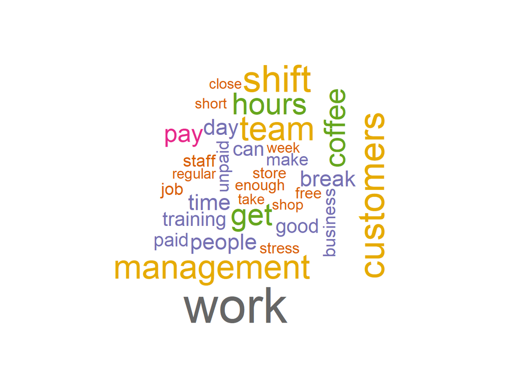

```r
# 6.1. Chmura słów - entire review ----

chmura_slow(tdm_entire_review_df)
```

> W swoich opiniach pracownicy zwracali uwagę przede wszystkim na klientów (“customers”), zespół (“team”) i sposób zarządzania (“management”). Sugeruje to, że są to aspekty, na które należy zwrócić największą uwagę.

# 6.2. Chmura słów - best thing

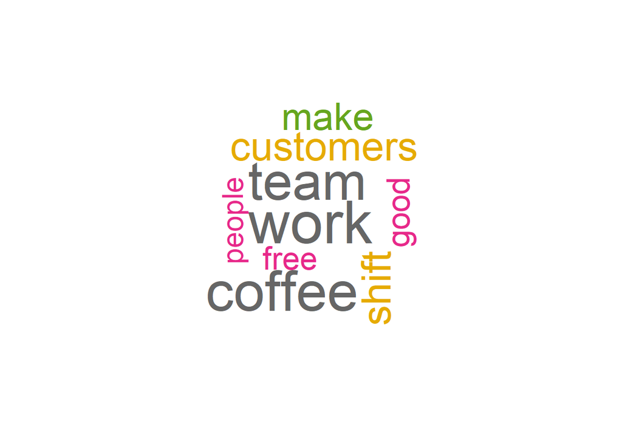

```r
# 6.2. Chmura słów - best thing ----

chmura_slow(tdm_best_thing_df)
```

> W pozytywnych aspektach pracownicy używają często słów “team”, “customers” i “people”, co wskazuje na to, że zespół i klienci byli pozytywnie postrzegani. Pojawienie się słowa “free” może mieć związek z darmową kawą dla pracowników, można to dalej sprawdzić z wykorzystaniem asocjacji. Może to też częściowo wyjaśniać pojawienie się słowa “coffee”, ale niekoniecznie.

# 6.3. Chmura słów - worst thing

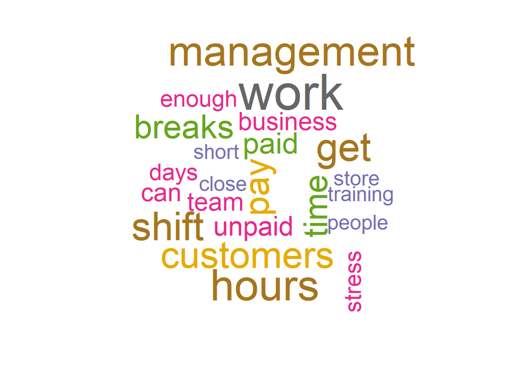

```r
# 6.3. Chmura słów - worst thing ----

chmura_slow(tdm_worst_thing_df)
```

> Pojawienie się słów “hours” i “time” może sugerować, że jednym z problemów były godziny pracy lub jak sugeruje dodatkowo występowanie “paid” i “unpaid” - brak wynagrodzenia za wszystkie przepracowane godziny. Podobnie jak w pozytywnych apektach, też pojawiają się słowa “customers”, “people” i “team”, a także dodatkowo “management”. Sugeruje to że część pracowników postrzega negatywnie swój zespół, a w szczególności zarządzanie w firmie. Pracownicy używali też słowa “breaks”, co może sugerować problemy z przerwami w pracy.

# 7. Topic modelling

```r
# 7. Topic modelling ----

# Funkcja, która na podstawie korpusu wizualizuje słowa o największej informatywności
# przy użyciu metody ukrytej alokacji Dirichleta (LDA) dla wyznaczonej liczby teamtów

top_terms_by_topic_LDA <- function(corpus, # korpus tekstu
                                   plot = TRUE, # domyślnie rysuje wykres
                                   k = number_of_topics) # liczba tematów
{
  # Utworzenie macierzy DTM
  DTM <- DocumentTermMatrix(corpus)

  # Pobranie indeksu każdej unikalnej wartości
  unique_indexes <- unique(DTM$i)
  # Pobranie z DTM podzbioru unikalnych wartości
  DTM <- DTM[unique_indexes, ]

  # Wykonanie LDA
  lda <- LDA(DTM, k = number_of_topics, control = list(seed = 132709052026))
  # Pobranie słów/tematów w uporządkowanym formacie tidy
  topics <- tidy(lda, matrix = "beta")

  # Pobranie dziesięciu najczęstszych słów dla każdego tematu
  top_terms <- topics  %>%
    group_by(topic) %>%
    top_n(10, beta) %>%
    ungroup() %>%
    arrange(topic, -beta) # Uporządkowanie słów w malejącej kolejności informatywności



  # Rysowanie wykresu (domyślnie plot = TRUE)
  if(plot == T){
    # Dziesięć najczęstszych słów dla każdego tematu
    top_terms %>%
      mutate(term = reorder(term, beta)) %>% # Sortowanie słów według wartości beta
      ggplot(aes(term, beta, fill = factor(topic))) + # Rysowanie beta według tematu
      geom_col(show.legend = FALSE) + # Wykres kolumnowy
      facet_wrap(~ topic, scales = "free") + # Każdy temat na osobnym wykresie
      labs(x = "Terminy", y = "β (ważność słowa w temacie)") +
      coord_flip() +
      theme_minimal() +
      scale_fill_brewer(palette = "Set1")
  }
  else{
    # Jeśli użytkownik nie chce wykresu zwraca listę posortowanych słów
    return(top_terms)
  }

}
```

# 7.1. Modelowanie tematów dla best_thing

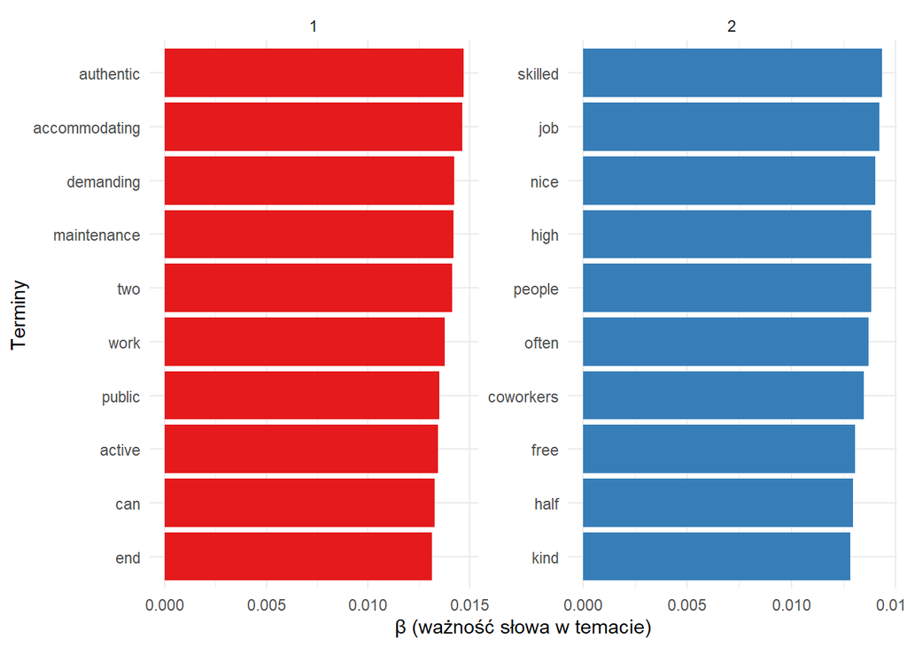

```r
# 7.1. Modelowanie tematów dla best_thing ----

number_of_topics = 2
top_terms_by_topic_LDA(tdm_best_thing_df$word)
```

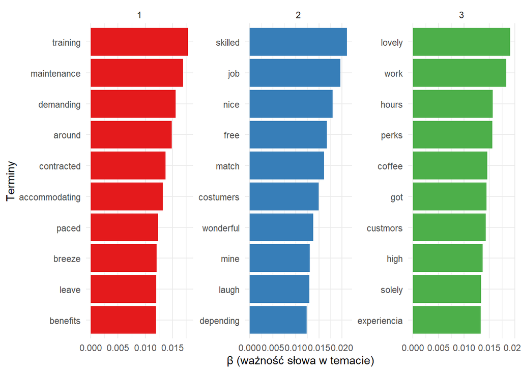

```r
number_of_topics = 3
top_terms_by_topic_LDA(tdm_best_thing_df$word)
```

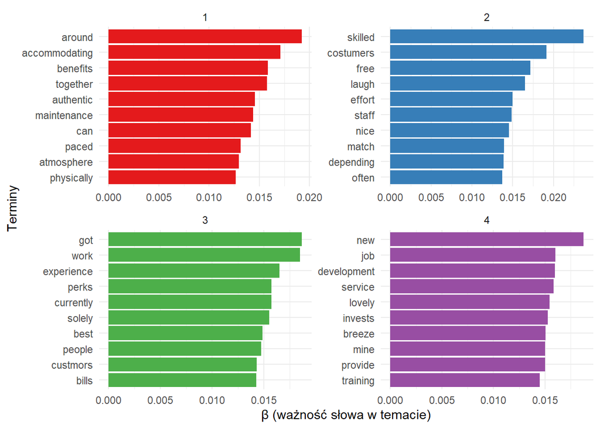

```r
number_of_topics = 4
top_terms_by_topic_LDA(tdm_best_thing_df$word)
```

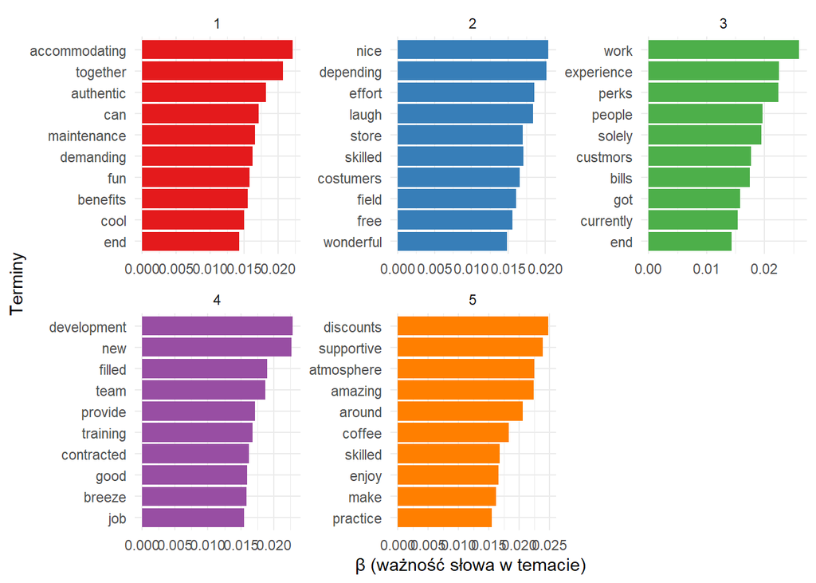

```r
number_of_topics = 5
top_terms_by_topic_LDA(tdm_best_thing_df$word)
```

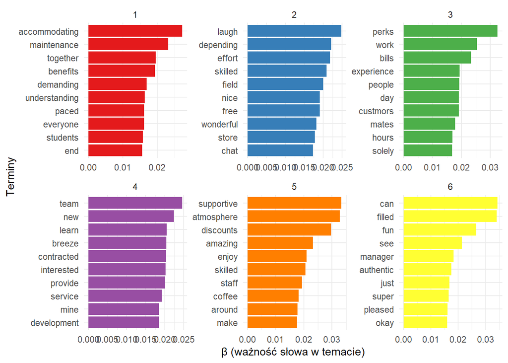

```r
number_of_topics = 6
top_terms_by_topic_LDA(tdm_best_thing_df$word)
```

> Najlepszy zdaje się podział na trzy tematy. Można zauważyć, że pierwszy temat odnosi się do ogólnych warunków pracy i jej tempa. Drugi temat ma związek z atmosferą i kontaktem z ludźmi, w tym klientami. Trzeci temat odnosi się do godzin pracy i dodatkowych korzyści.

# 7.2. Modelowanie tematów dla worst_thing

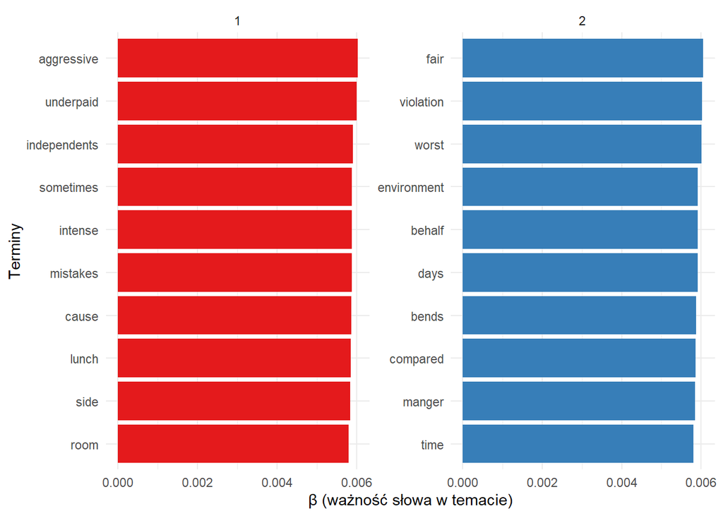

```r
# 7.2. Modelowanie tematów dla worst_thing ----

number_of_topics = 2
top_terms_by_topic_LDA(tdm_worst_thing_df$word)
```

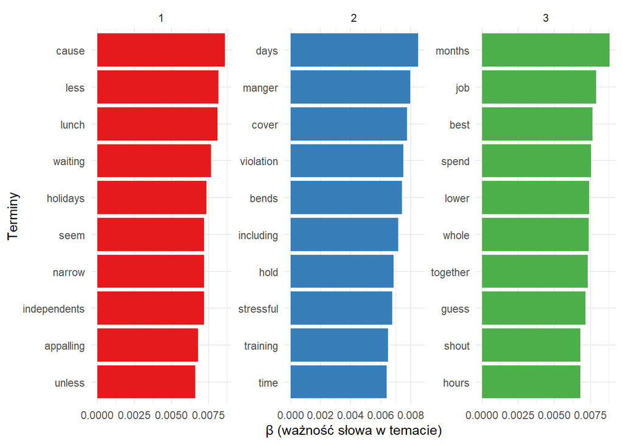

```r
number_of_topics = 3
top_terms_by_topic_LDA(tdm_worst_thing_df$word)
```

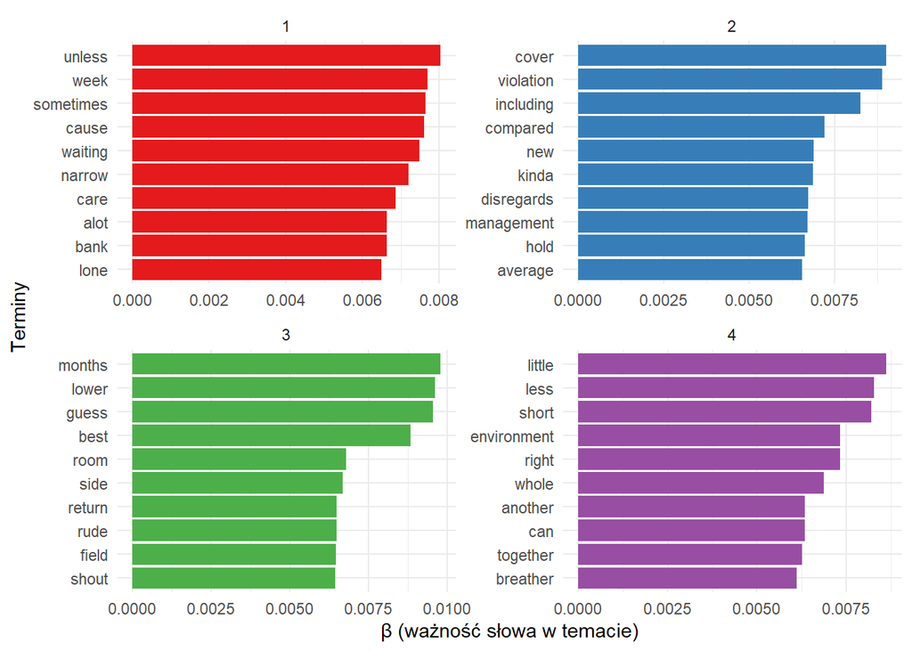

```r
number_of_topics = 4
top_terms_by_topic_LDA(tdm_worst_thing_df$word)
```

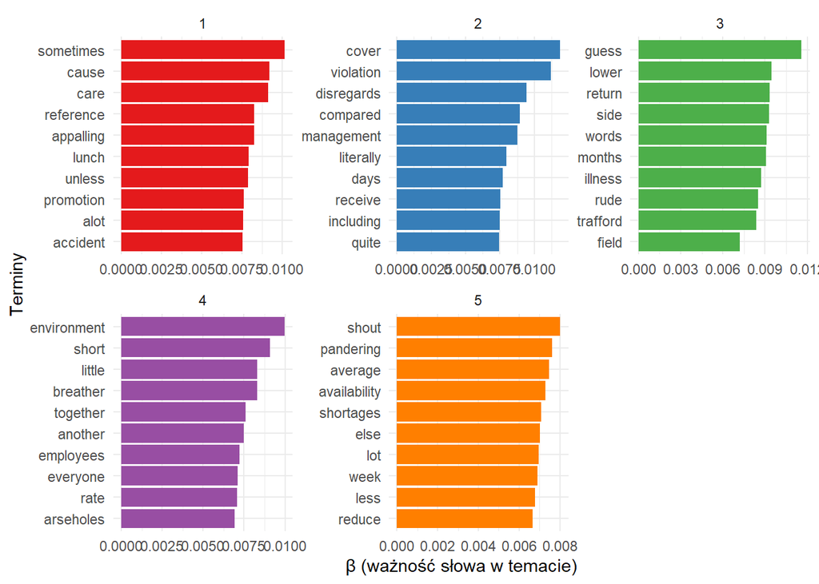

```r
number_of_topics = 5
top_terms_by_topic_LDA(tdm_worst_thing_df$word)
```

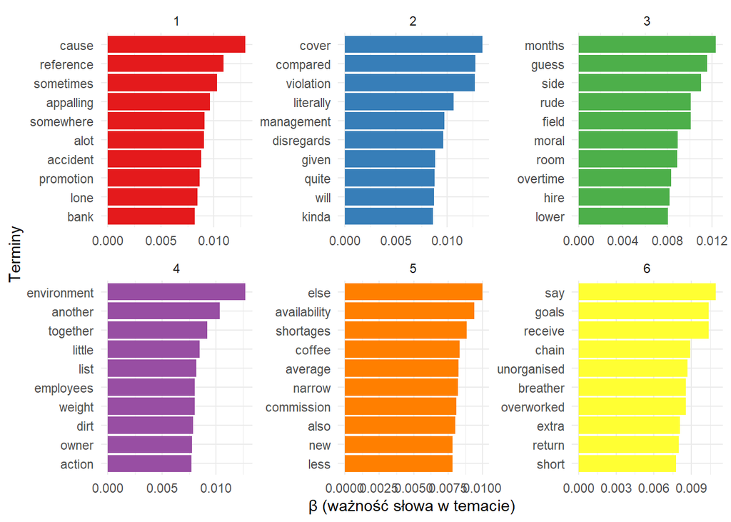

```r
number_of_topics = 6
top_terms_by_topic_LDA(tdm_worst_thing_df$word)
```

> Podział na trzy tematy zdaje się najlepszy. Pierwszy temat odnosi się do potencjalnych problemów z przerwami na lunch i problemów z wolnym (“holidays”). Drugi temat może dotyczyć problemów z menedżerami, naruszeniami i stresującym charakterem pracy. Trzeci temat może mieć związek z czasem i napięciami w pracy (“shout”).

# 8. Asocjacje

```r
# 8. Asocjacje ----

# Funkcja tworząca wykres asocjacji

wykres_asocjacji <- function(target_word, cor_limit) {
  # Oblicz asocjacje dla tego słowa
  associations <- findAssocs(tdm_entire_review, target_word, corlimit = cor_limit)
  assoc_vector <- associations[[target_word]]
  assoc_sorted <- sort(assoc_vector, decreasing = TRUE)


  # Ramka danych
  assoc_df <- data.frame(
    word = factor(names(assoc_sorted), levels = names(assoc_sorted)[order(assoc_sorted)]),
    score = assoc_sorted
  )

  # Wykres lizakowy z natężeniem
  # na podstawie wartości korelacji score:
  ggplot(assoc_df, aes(x = score, y = reorder(word, score), color = score)) +
    geom_segment(aes(x = 0, xend = score, y = word, yend = word), size = 1.2) +
    geom_point(size = 4) +
    geom_text(aes(label = round(score, 2)), hjust = -0.3, size = 3.5, color = "black") +
    scale_color_gradient(low = "#bcbddc", high = "#54278f") +
    scale_x_continuous(
      limits = c(0, max(assoc_df$score) + 0.1),
      expand = expansion(mult = c(0, 0.2))
    ) +
    theme_minimal(base_size = 12) +
    labs(
      title = paste0("Asocjacje z terminem: '", target_word, "'"),
      subtitle = paste0("Próg r ≥ ", cor_limit),
      x = "Współczynnik korelacji Pearsona",
      y = "Słowo",
      color = "Natężenie\nskojarzenia"
    ) +
    theme(
      plot.title = element_text(face = "bold"),
      axis.title.x = element_text(margin = margin(t = 10)),
      axis.title.y = element_text(margin = margin(r = 10)),
      legend.position = "right"
    )
}
```

# 8.1. Asocjacje ze słowem “work”

```r
# 8.1. Asocjacje ze słowem "work" ----

findAssocs(tdm_entire_review, "work", 0.5)
```

```
## $work
##         week        space         poor          day        store  requirement
##         0.63         0.61         0.60         0.58         0.58         0.57
##         come        extra        whole     accident       active         also
##         0.56         0.56         0.56         0.52         0.52         0.52
##       anyway        apart        bends   blackboard      blender          buy
##         0.52         0.52         0.52         0.52         0.52         0.52
##       centre        chain         chat   commission  commitments    deliveroo
##         0.52         0.52         0.52         0.52         0.52         0.52
##    demanding      ensures         face         fall          far         food
##         0.52         0.52         0.52         0.52         0.52         0.52
##       happen         home          hot independents         ipad    isolation
##         0.52         0.52         0.52         0.52         0.52         0.52
##         live      looking  maintenance         open       orders        paced
##         0.52         0.52         0.52         0.52         0.52         0.52
##      parking   physically      prepare        queue       random       really
##         0.52         0.52         0.52         0.52         0.52         0.52
##   relatively    resources       return         room         rubs        sales
##         0.52         0.52         0.52         0.52         0.52         0.52
##         sell        shout          sit       solely    somewhere        spend
##         0.52         0.52         0.52         0.52         0.52         0.52
##        think          til         told     trafford      waiting        world
##         0.52         0.52         0.52         0.52         0.52         0.52
##         zero       drinks
##         0.52         0.51
```

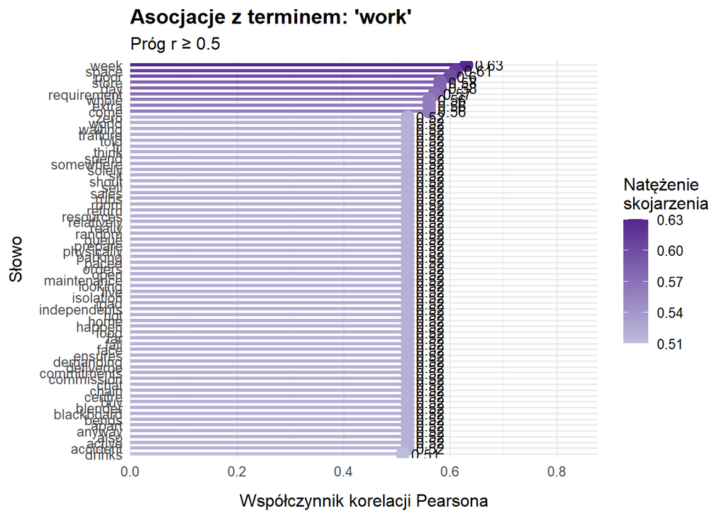

```r
# Wytypowane słowo i próg asocjacji
target_word <- "work"
cor_limit <- 0.5

wykres_asocjacji(target_word, cor_limit)
```

> Asocjacji z “work” jest dużo, trudno wyciągać bardziej szczegółowe wnioski na podstawie wyników.

# 8.2. Asocjacje ze słowem “holidays”

```r
# 8.2. Asocjacje ze słowem "holidays" ----

findAssocs(tdm_entire_review, "holidays", 0.5)
```

```
## $holidays
##     periods        bank compensated     contact    extended      forced
##        0.86        0.81        0.81        0.81        0.81        0.81
##     forever        hold    horribly    national      refuse     sundays
##        0.81        0.81        0.81        0.81        0.81        0.81
##    overtime       right
##        0.56        0.56
```

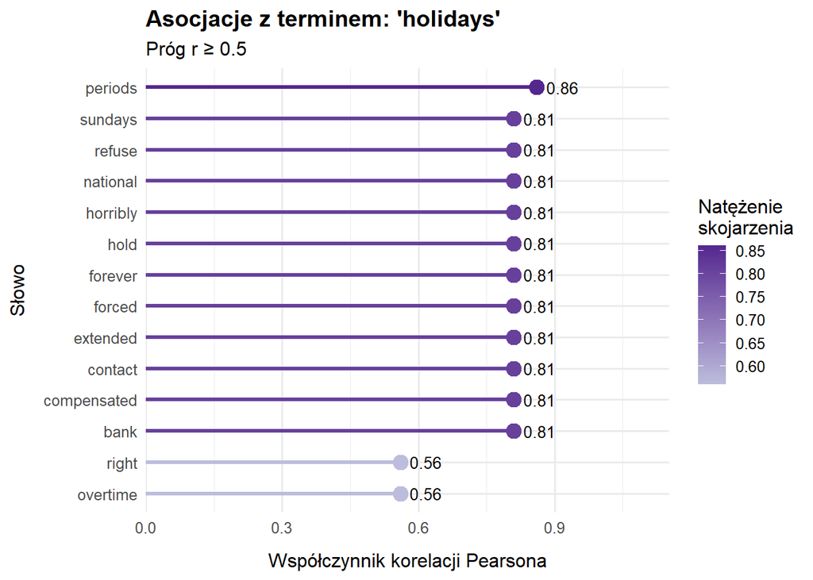

```r
# Wytypowane słowo i próg asocjacji
target_word <- "holidays"
cor_limit <- 0.5

wykres_asocjacji(target_word, cor_limit)
```

> Asocjacje ze słowamu “refuse”, “horribly”, “forced” mogą sugerować problemy z uzyskiwaniem wolnego.

# 8.3. Asocjacje ze słowem “free”

```r
# 8.3. Asocjacje ze słowem "free" ----

findAssocs(tdm_entire_review, "free", 0.5)
```

```
## $free
## shift
##  0.65
```

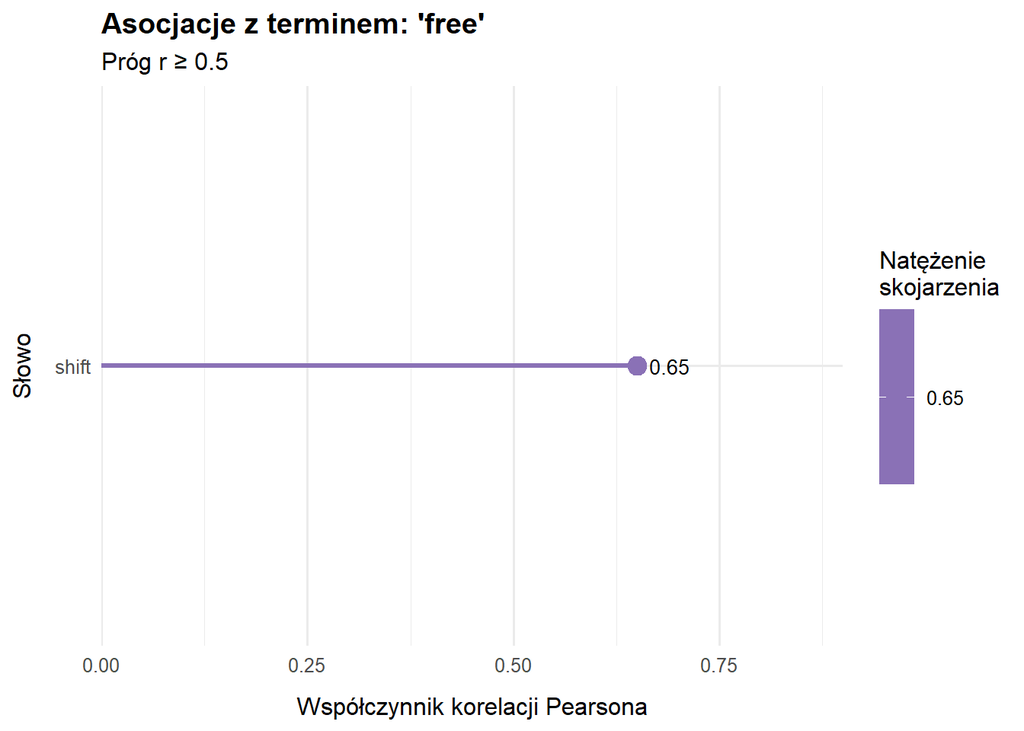

```r
# Wytypowane słowo i próg asocjacji
target_word <- "free"
cor_limit <- 0.5

wykres_asocjacji(target_word, cor_limit)
```

> Asocjacje ze słowami “shift” może wskazywać na coś darmowego w trakcie zmiany.

# 8.4. Asocjacje ze słowem “hours”

```r
# 8.4. Asocjacje ze słowem "hours" ----

findAssocs(tdm_entire_review, "hours", 0.5)
```

```
## $hours
## constantly atmosphere     beyond complaints contracted       deal   entitled
##       0.55       0.51       0.51       0.51       0.51       0.51       0.51
##    example      lunch  pandering   properly ridiculous  shortages   students
##       0.51       0.51       0.51       0.51       0.51       0.51       0.51
##        uni
##       0.51
```

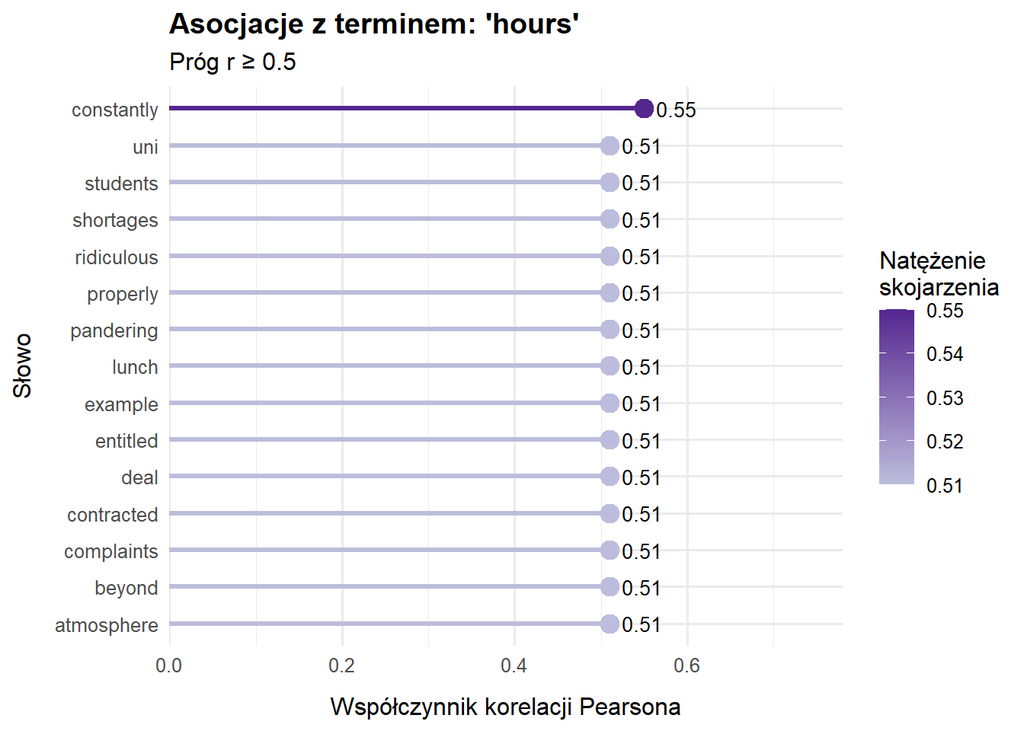

```r
# Wytypowane słowo i próg asocjacji
target_word <- "hours"
cor_limit <- 0.5

wykres_asocjacji(target_word, cor_limit)
```

> Pojawianie się asocjacji ze “students” i “uni” może sugerować godziny pracy, które odpowiadają studentom. Chociaż możliwe jest też np., że pracownicy zwracali uwagę na godziny, w których najczęściej przychodzą studenci.